# EDA - STUDENT BEHAVIOUR

### 4. Czy istnieje związek między czasem spędzanym na nauce oraz tym, czy student pracuje?

Czy jeśli student pracuje, to spędza mniej czasu na nauce? Wydaję się, że tak może być. Sprawdzę to za pomocą wykresu kolumnowego

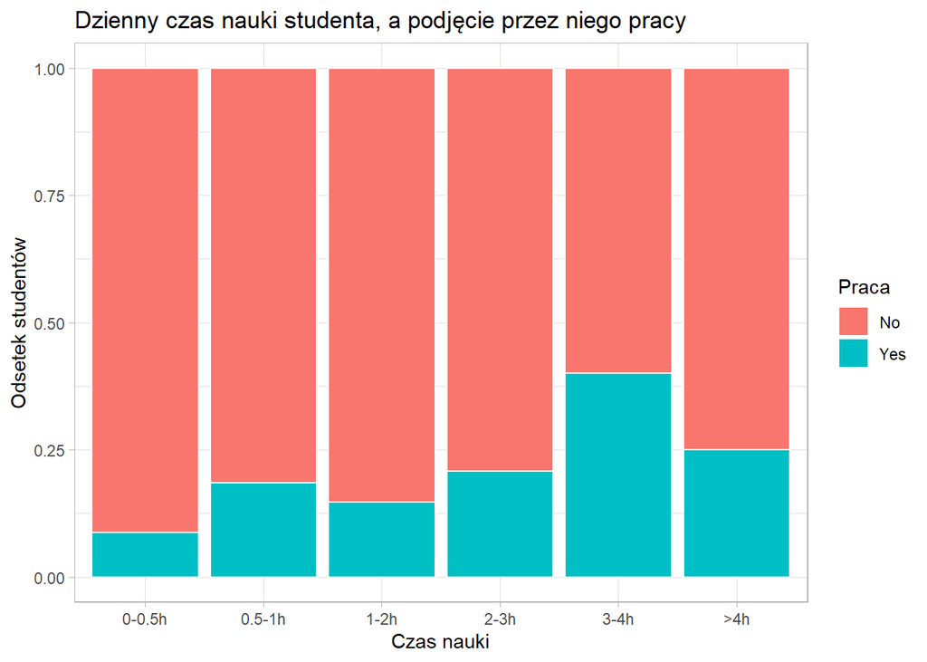

```r
dane %>%
  ggplot() +
  geom_bar(aes(x = CzasNauki, fill = Praca),
           color = "white",
           position = "fill") +
  theme_light() +
  labs(title = "Dzienny czas nauki studenta, a podjęcie przez niego pracy",
       x = "Czas nauki",
       y = "Odsetek studentów",
       fill = "Praca")
```

```r
table(dane[,c("CzasNauki", "Praca")])
```

```
##          Praca
## CzasNauki No Yes
##    0-0.5h 42   4
##    0.5-1h 66  15
##    1-2h   52   9
##    2-3h   19   5
##    3-4h    9   6
##    >4h     6   2
```

Raczej to, że student pracuje nie sprawia, że mniej się uczy. Wręcz można powiedzieć, że jest odwrotnie: wśród osób uczących się dłużej, coraz większy odsetek zajmują osoby pracujące. Jest to dość nieoczywiste, gdyż wydawałoby się, że praca powoduje, że czasu na naukę będzie mniej, ale jak widać czas nauki bardziej wynika z innych czynników, którym z pewnością jest motywacja studenta.

### 5. Czy status finansowy studenta wpływa na jego decyzję o podjęciu pracy w niepełnym wymiarze godzin?

Przypuszczam, że gorszy status finansowy studenta powoduje, że podejmuje on pracę dodatkową. Z drugiej jednak strony podjęcie pracy może powodować, że status finansowy studenta jest lepszy. Zbadam to za pomocą funkcji *table()*

```r
table(dane[,c("Praca", "StatusFinansowy")])
```

```
##      StatusFinansowy
## Praca Awful Bad Good Fabulous
##   No     10  71  111        2
##   Yes     4  17   18        2
```

Wstępnie widzimy, że zdecydowana większość studentów o dobrej (“Good”) sytuacji finansowej nie podejmuje pracy.

Dla lepszej czytelności przedstawiam dane na wykresie kolumnowym, pokazującym odsetek studentów, którzy podejmują i nie podejmują pracy na poszczególnych poziomach statusu finansowego

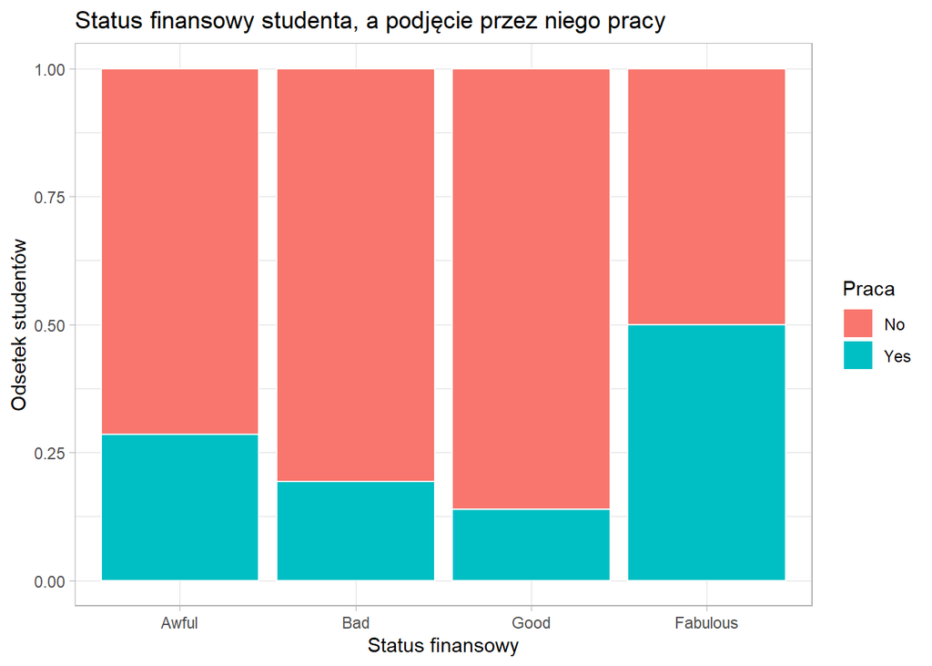

```r
dane %>%
  ggplot() +
  geom_bar(aes(x = StatusFinansowy, fill = Praca),
           color = "white",
           position = "fill") +
  theme_light() +
  labs(title = "Status finansowy studenta, a podjęcie przez niego pracy",
       x = "Status finansowy",
       y = "Odsetek studentów",
       fill = "Praca")
```

Tu jeszcze dokładniej widać, że im lepszy status finansowy, tym mniejszy odsetek studentów podejmuje pracę w niepełnym wymiarze godzin, z wyjątkiem ostatniego poziomu “Fabulous”, ale jest to spowodowane tym, że tylko 4 studentów określiło tak swój status finansowy.

### 6. Czy oceny z uczelni uzyskiwane na poszczególnych kierunkach różnią się znacząco od siebie jak wygląda struktura płci na poszczególnych kierunkach?

Myślę, że kierunki typowo informatyczne są zazwyczaj bardziej wymagające, dlatego na kierunku *BCA* i *B.com ISM* spodziewam się gorszych ocen. W celu analizy generuję wykresy pudełkowe z wąsami: wartości ocen z uczelni z podziałem na kierunki.

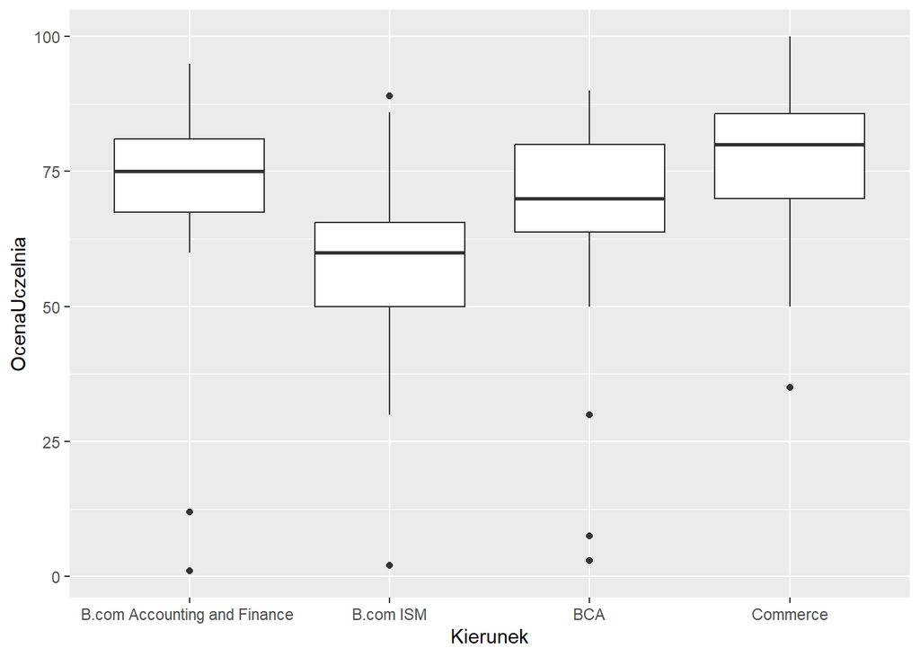

```r
dane %>%
  ggplot() +
  geom_boxplot(aes(x = Kierunek, y = OcenaUczelnia))
```

Teraz badam, ile kobiet, a ile mężczyzn studiuje na poszczególnych kierunkach. Przypuszczam, że na kierunkach informatycznych, czyli *BCA* i *B.com ISM* będą przeważać mężczyźni, natomiast dużo kobiet może być na kierunku *B.com Accounting and Finance*.

```r
table(dane[,c("Kierunek", "Plec")])
```

```
##                                Plec
## Kierunek                        Female Male
##   B.com Accounting and Finance       6    9
##   B.com ISM                          6   22
##   BCA                               38   94
##   Commerce                          29   31
```

### 7. Jakie są główne hobby/zainteresowania studentów studiujących na określonych kierunkach

Przypuszczam, że większe zainteresowanie grami video będą wykazywać studenci kierunków bardziej informatycznych, to znaczy BCA lub B.com ISM, natomiast studenci kierunków Commerce i B.com Accounting and Finance będą się interesować bardziej czytaniem książek lub ewentualnie kinem.  
Sprawdzam moje przypuszczenia za pomocą wykresu kolumnowego dla każdego kierunku z podziałem na hobby.

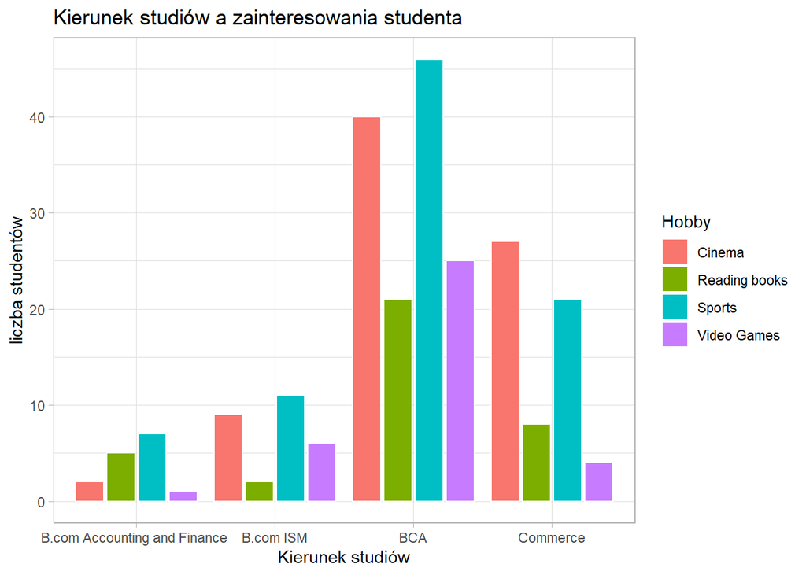

```r
dane %>%
  ggplot() +
  geom_bar(aes(x = Kierunek, fill = Hobby),
           color = "white",
           position = "dodge2") +
  theme_light() +
  labs(title = "Kierunek studiów a zainteresowania studenta",
       x = "Kierunek studiów",
       y = "liczba studentów",
       fill = "Hobby")
```

Na wszystkich kierunkach wśród studentów dominującym hobby (lub znajdującym się na drugim miejscu popularności w przypadku kierunku *Commerce*) jest sport. Drugim najpopularniejszym zainteresowaniem, z wyjątkiem kierunku *B.com Accounting and Finance*, gdzie popularnością cieszy się czytanie książek (Reading books), jest kino (Cinema). Co do moich przypuszczeń: rzeczywiście, patrząc na dwa pozostałe hobby (czytanie książek i gry video), w przypadku kierunków *BCA* i *B.com ISM* gry video stanowią hobby większej liczby studentów niż czytanie książek, a w przypadku kierunków *Commerce* i *B.com Accounting and Finance* - odwrotnie. Przypuszczenia okazały się słuszne.

## 8. Jakie inne wartości zmiennych mają studenci, którzy osiągają najlepsze, a jakie, którzy osiągają najgorsze oceny na uczelni?

Badam, ile trzeba się uczyć, żeby osiągać najlepsze wyniki,

```r
najlepsi_studenci <- dane %>%
  arrange(desc(OcenaUczelnia)) %>%
  head(3)
najlepsi_studenci
```

```
##   Certyfikat   Plec Kierunek Wzrost Waga Ocena10 Ocena12 OcenaUczelnia
## 1        Yes Female Commerce    151   55    93.8    83.5           100
## 2        Yes Female Commerce    152   65    97.0    80.0           100
## 3        Yes   Male Commerce    165   75    65.0    75.0            97
##           Hobby CzasNauki PreferowanaPoraNauki OczekiwaneWynagrodzenie
## 1 Reading books      1-2h              Morning                   15000
## 2 Reading books      3-4h              Morning                   15000
## 3        Cinema    0-0.5h              Anytime                   15000
##   CzyLubiszSwojDyplom DalszaKariera SocialMedia CzasDojazdu    Stres
## 1                 Yes           75%      1-1.5h      0.5-1h     Good
## 2                 Yes          100%      0.5-1h      0-0.5h     Good
## 3                 Yes           50%      1-1.5h      0-0.5h Fabulous
##   StatusFinansowy Praca
## 1            Good   Yes
## 2            Good   Yes
## 3            Good   Yes
```

Wszyscy trzej najlepsi studenci są z kierunku *Commerce*, pracują, ukończyli kurs certyfikujący i mają dobrą sytuację finansową i dobry, lub nawet świetny poziom stresu, a także krótko dojeżdzają na uczelnię. Co ciekawe dwaj najlepsi studenci to kobiety, których hobby jest czytanie książek, a preferowaną porą nauki: rano. Interesujący jest fakt, że każdy z tych studentów ma inny czas nauki: pierwszy uczy się 1-2h, drugi 3-4h, a trzeci tylko mniej niż pół godziny.

```r
najgorsi_studenci <- dane %>%
  arrange(OcenaUczelnia) %>%
  head(3)
najgorsi_studenci
```

```
##   Certyfikat Plec                      Kierunek Wzrost Waga Ocena10 Ocena12
## 1         No Male B.com Accounting and Finance     155   55      73      72
## 2        Yes Male                     B.com ISM    173   92      54      65
## 3        Yes Male                           BCA    165   50      70      63
##   OcenaUczelnia         Hobby CzasNauki PreferowanaPoraNauki
## 1             1 Reading books      1-2h                Night
## 2             2        Cinema    0-0.5h              Anytime
## 3             3 Reading books      1-2h              Morning
##   OczekiwaneWynagrodzenie CzyLubiszSwojDyplom DalszaKariera SocialMedia
## 1                   15000                 Yes           75%      0-0.5h
## 2                   23000                 Yes          100%         >2h
## 3                   15000                 Yes           75%      1-1.5h
##   CzasDojazdu Stres StatusFinansowy Praca
## 1      0.5-1h  Good            Good    No
## 2      1-1.5h  Good            Good    No
## 3      1-1.5h  Good            Good    No
```

Wszyscy trzej najgorsi studenci to mężczyźni i wszyscy trzej nie pracują. Mają dobry poziom stresu i dobry status finansowy. Najgorszy student nie ukończył kursu certyfikującego. Dwóch z trzech studentów interesuje się czytaniem książek, co powszechnie jest uważane za symbol mądrości, dlatego też wyniki te mogą być zastanawiające.